# What is Jupyter ?

Project Jupyter exists to develop open-source software, open-standards, and services for interactive computing across dozens of programming languages.

- Jupyter supports over 40 programming languages, including Python, R, Julia, and Scala.
- Notebooks can be shared with others using email, Dropbox, GitHub and the Jupyter Notebook Viewer.
- Your code can produce rich, interactive output: HTML, images, videos, LaTeX, and custom MIME types.
- Leverage big data tools, such as Apache Spark, from Python, R and Scala. Explore that same data with pandas, scikit-learn, ggplot2, TensorFlow.Your code can produce rich, interactive output: HTML, images, videos, LaTeX, and custom MIME types.

# Install

# Anaconda

> The open-source Anaconda Distribution is the easiest way to perform Python/R data science and machine learning on Linux, Windows, and Mac OS X. With over 15 million users worldwide, it is the industry standard for developing, testing, and training on a single machine Download from https://www.anaconda.com/distribution/

[figure not shown]

# WSL

https://towardsdatascience.com/setting-up-a-data-science-environment-using-windows-subsystem-for-linux-wsl-c4b390803dd

# Run

To start the notebook server open a terminal and run

`jupyter notebook`

Open a web browser on the web interface (http://localhost:8888/)

[figure not shown]

Keep a log of activities in the terminal

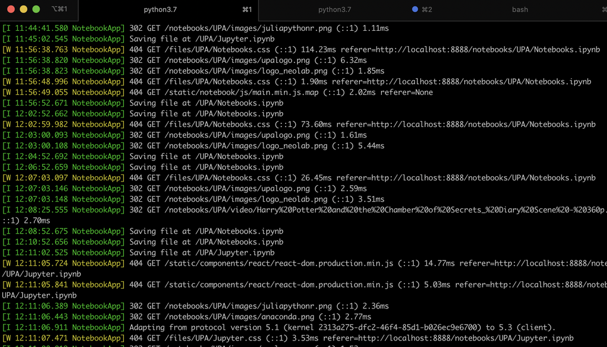

# Narratives

> Narratives are collaborative, shareable, publishable, and reproducible. We believe that Narratives help both yourself and other researchers by sharing your use of Jupyter projects, technical specifics of your deployment, and installation and configuration tips so that others can learn from your experiences.
- Data Exploration
- Extensions
- Publishing
- Hub
- Data Science
- Education
- Enterprise

[See](https://jupyter.readthedocs.io/en/latest/use-cases/content-user.html)

# Usage

A new notebook may be created at any time, either from the dashboard, or using the File ‣ New menu option from within an active notebook. The new notebook is created within the same directory and will open in a new browser tab. It will also be reflected as a new entry in the notebook list on the dashboard.

[figure not shown]

# Cells

## Code Cell

A code cell allows you to edit and write new code, with full syntax highlighting and tab completion. The programming language you use depends on the kernel, and the default kernel (IPython) runs Python code.

When a code cell is executed, code that it contains is sent to the kernel associated with the notebook. The results that are returned from this computation are then displayed in the notebook as the cell’s output. The output is not limited to text, with many other possible forms of output are also possible, including matplotlib figures and HTML tables (as used, for example, in the pandas data analysis package). This is known as IPython’s rich display capability.

```python
print("Hello World");
```

```
Hello World
```

## Markdown Cell

You can document the computational process in a literate way, alternating descriptive text with code, using rich text. In IPython this is accomplished by marking up text with the Markdown language. The corresponding cells are called Markdown cells. The Markdown language provides a simple way to perform this text markup, that is, to specify which parts of the text should be emphasized (italics), bold, form lists, etc.

# Markdown is cool

Can easily add [links](https://commonmark.org/)

## Headings

- List

## Raw Cell

Raw cells provide a place in which you can write output directly. Raw cells are not evaluated by the notebook. When passed through nbconvert, raw cells arrive in the destination format unmodified. For example, you can type full LaTeX into a raw cell, which will only be rendered by LaTeX after conversion by nbconvert.

# Editing Cell

- Cells can be edited by double clicking (or Enter)
- When the Cell is blue is selected, green is editable
- Shift+Enter Runs the cell

[Examples] https://jupyter-notebook.readthedocs.io/en/stable/examples/Notebook/Typesetting%20Equations.html

# Kernels

- Kernels are asynchorous process to execute code
- By default only Python is available, others can be installed
- [List of Kernels] https://github.com/jupyter/jupyter/wiki/Jupyter-kernels

# Export Notebook

Using nbconvert enables: presentation of information in familiar formats, such as PDF. publishing of research using LaTeX and opens the door for embedding notebooks in papers. collaboration with others who may not use the notebook in their work. sharing contents with many people via the web using HTML. Format:

- latex
- pdf
- html
- slides

https://nbconvert.readthedocs.io/en/latest/install.html

# Slides

# RISE

https://github.com/damianavila/RISE `conda install -c conda-forge rise`

## Export

`jupyter nbconvert Notebooks.ipynb Jupyter.ipynb --to slides --post serve --SlidesExporter.reveal_theme=sky --SlidesExporter.reveal_scroll=True`

# PDF

jupyter nbconvert Notebooks.ipynb --to pdf

# Jupyter Lab

JupyterLab is a next-generation web-based user interface for Project Jupyter (June 2019 version 1.0)

## Install

`conda install -c conda-forge jupyterlab`

[figure not shown]

https://jupyterlab.readthedocs.io/en/stable/getting_started/overview.html#

# Lab Extension

```
conda install -c conda-forge nodejs
brew install node
```

# Pelican and Jupyter Notebooks

https://janakiev.com/blog/pelican-jupyter/